# R Notebook

# TO DO

- transforming the dataset (if necessary)
- Ridge and Lasso (?)
- Plots (if number of variables permits it)
- introduction of groups (for LMM)

```r
#DIRECTORIES
rm(list=ls())
graphics.off()
root_proj_dir = "../../"
dataset_path = paste(root_proj_dir,"data/df_pca_scores.csv",sep="")
include_path = paste(root_proj_dir,"src/include/Utilities.R",sep="")
#INCLUDING UTILITIES
source(include_path)
#IMPORTING THE DATASET
data <- read.csv(file=dataset_path)
head(data)
library(mvtnorm)
library(MASS)
library(car)
library(rgl)
library(leaps)
library(ISLR)
library(glmnet)
library(lme4)
library(nlmeU) ## --> for the dataset
library(nlme)  ## --> for models implementation

library(corrplot)
library(lattice)
library(plot.matrix)


library(insight)

library(ggplot2)
```

```r
#DIRECTORIES
rm(list=ls())
graphics.off()
root_proj_dir = "../../"
dataset_path = paste(root_proj_dir,"data/df_pca_scores.csv",sep="")
include_path = paste(root_proj_dir,"src/include/Utilities.R",sep="")
#INCLUDING UTILITIES
source(include_path)
#IMPORTING THE DATASET
data <- read.csv(file=dataset_path)
head(data)
```

|  | X | CNT | col1_tec | col2_tec | col3_tec | col4_tec | col5_tec | col1_psi | col2_psi | col3_psi | col4_psi | col5_psi | col6_psi | col7_psi | col1_clt | col2_clt | col3_clt | col1_fam | col1_tch | col2_tch | col3_tch | col4_tch | col1_sch | col2_sch | col3_sch | col4_sch |
| --- | --- | --- | --- | --- | --- | --- | --- | --- | --- | --- | --- | --- | --- | --- | --- | --- | --- | --- | --- | --- | --- | --- | --- | --- | --- | --- |
| 1 | 1 | HRV | -0.960485964 | -0.8623715 | -0.4472239 | 0.3194147 | 0.37348598 | -0.05002119 | -0.1616745 | -0.13874355 | -0.17945555 | -0.02557872 | -0.03670311 | -0.11741006 | -1.405136 | -0.1116010 | -1.2833209 | -2.804531 | 0.40089382 | 0.5037817 | -0.5435958 | 1.81938546 | -0.1812443 | -0.04867541 | 1.3011994 | 3.000000 |
| 2 | 2 | HRV | -0.930350935 | -2.3880658 | -0.2544000 | 0.2084186 | 0.40483107 | -0.09695467 | 0.1298853 | -0.25229189 | -0.05681765 | 0.06419948 | -0.31374115 | 0.05028026 | -1.396500 | -0.5233104 | -1.2201329 | -2.952773 | -0.18131986 | 0.3086920 | -0.4757922 | 0.41391939 | -0.7500164 | 0.02024426 | 0.7568438 | 2.000000 |
| 3 | 3 | HRV | -0.027736152 | -1.2253232 | -0.2406970 | 0.5114644 | -0.34922567 | -0.08549125 | -0.3632239 | -0.03415793 | -0.07649567 | 0.05007223 | 0.35854184 | -0.15421347 | -1.334490 | -1.2922865 | -1.6085216 | -1.128376 | -0.06396184 | 0.3727568 | -0.6048914 | 0.02775139 | -0.6712683 | -0.23916223 | -1.0454269 | 1.549587 |
| 4 | 4 | HRV | -0.002071564 | 0.2202879 | 0.0498378 | 1.0159640 | 0.55805991 | 0.41176331 | -0.1491985 | 0.42114995 | 0.74050064 | -0.23086063 | 0.17338832 | 0.24312019 | 2.187956 | 0.1197241 | -0.3125705 | 3.532404 | -0.29388660 | 0.7587037 | -0.6602951 | -0.30228267 | 1.7123630 | 0.09107799 | -1.3077921 | 3.000000 |
| 5 | 5 | HRV | -0.686584997 | -1.6805225 | -0.3973942 | 0.6745688 | 0.03411918 | -0.31880054 | -0.3745939 | -0.56443945 | -0.24323707 | 0.04265235 | -0.18960669 | 0.13278023 | -1.894553 | -0.2216109 | -0.6535818 | -2.415045 | -0.26613860 | 0.4397254 | -0.6373503 | 2.29348868 | -1.0333030 | 0.31148068 | 0.2127385 | 0.000000 |
| 6 | 6 | HRV | -1.434214250 | -2.1182310 | 0.2314077 | 0.4145982 | 1.68254128 | 0.41765706 | 0.4116224 | -0.26388008 | 0.17721006 | -0.03815568 | -0.08381894 | 0.04728069 | -1.366873 | -0.3092975 | -2.3297756 | -2.488011 | -0.29087946 | 0.5225239 | -0.6745652 | 1.02856763 | -0.7415349 | -0.54155175 | 1.9803240 | 0.000000 |

```r
library(mvtnorm)
library(MASS)
library(car)
library(rgl)
library(leaps)
library(ISLR)
library(glmnet)
library(lme4)
library(nlmeU) ## --> for the dataset
library(nlme)  ## --> for models implementation
library(corrplot)
library(lattice)
library(plot.matrix)


library(insight)

library(ggplot2)
```

# choice of the model

total_model = c(“ATTLNACT”,“EMOSUPS”,“COMPETE”,“GFOFAIL”,“EUDMO”,“RESILIENCE”,“BELONG”,“BEINGBULLIED”, “PERFEED”,“CREACTIV”,“STRATIO”,“SCHSIZE”,“CLSIZE”,“EDUSHORT”,“STAFFSHORT”,“STUBEHA”,“TMINS”, “JOYREAD”,“CULTPOSS”,“HEDRES”,“SCREADCOMP”,“COMPICT”,“ICTCLASS”,“ICTHOME”,“ICTOUTSIDE”,“ICTRES”, “ENTUSE”,“HOMESCH”,“USESCH”,“INTICT”,“AUTICT”) response_variable_total = “SWBP”

tech <- c(“ICTCLASS”,“ICTHOME”,“ICTOUTSIDE”,“ICTRES”,“ENTUSE”,“HOMESCH”,“USESCH”,“INTICT”,“AUTICT”) tech2 <- c(“AUTICT”,“INTICT”) response_variable_tech = “COMPICT” ########

culture = c(“JOYREAD”,“CULTPOSS”,“HEDRES”,“SCREADCOMP”) TMINS=data$MMINS+data$LMINS response_variable_culture = “TMINS” ########

psychology = c(“ATTLNACT”,“EMOSUPS”,“COMPETE”,“EUDMO”,“GFOFAIL”,“RESILIENCE”,“BELONG”,“BEINGBULLIED”,“PERFEED”) response_variable_psy = “SWBP” ########

school_prof = c(“STRATIO”,“SCHSIZE”,“CLSIZE”,“EDUSHORT”,“STAFFSHORT”,“STUBEHA”) response_variable_school = “CREACTIV” ########

school_prof_2 = c(“SCHSIZE”,“CLSIZE”,“STAFFSHORT”) response_variable_school_2 = “STRATIO” ########################

```r
data$X <- NULL
data$CNT <- as.factor(data$CNT)
#data <- data[,23:74] #excluding target variables
head(data)
```

|  | CNT | col1_tec | col2_tec | col3_tec | col4_tec | col5_tec | col1_psi | col2_psi | col3_psi | col4_psi | col5_psi | col6_psi | col7_psi | col1_clt | col2_clt | col3_clt | col1_fam | col1_tch | col2_tch | col3_tch | col4_tch | col1_sch | col2_sch | col3_sch | col4_sch |
| --- | --- | --- | --- | --- | --- | --- | --- | --- | --- | --- | --- | --- | --- | --- | --- | --- | --- | --- | --- | --- | --- | --- | --- | --- | --- |
| 1 | HRV | -0.960485964 | -0.8623715 | -0.4472239 | 0.3194147 | 0.37348598 | -0.05002119 | -0.1616745 | -0.13874355 | -0.17945555 | -0.02557872 | -0.03670311 | -0.11741006 | -1.405136 | -0.1116010 | -1.2833209 | -2.804531 | 0.40089382 | 0.5037817 | -0.5435958 | 1.81938546 | -0.1812443 | -0.04867541 | 1.3011994 | 3.000000 |
| 2 | HRV | -0.930350935 | -2.3880658 | -0.2544000 | 0.2084186 | 0.40483107 | -0.09695467 | 0.1298853 | -0.25229189 | -0.05681765 | 0.06419948 | -0.31374115 | 0.05028026 | -1.396500 | -0.5233104 | -1.2201329 | -2.952773 | -0.18131986 | 0.3086920 | -0.4757922 | 0.41391939 | -0.7500164 | 0.02024426 | 0.7568438 | 2.000000 |
| 3 | HRV | -0.027736152 | -1.2253232 | -0.2406970 | 0.5114644 | -0.34922567 | -0.08549125 | -0.3632239 | -0.03415793 | -0.07649567 | 0.05007223 | 0.35854184 | -0.15421347 | -1.334490 | -1.2922865 | -1.6085216 | -1.128376 | -0.06396184 | 0.3727568 | -0.6048914 | 0.02775139 | -0.6712683 | -0.23916223 | -1.0454269 | 1.549587 |
| 4 | HRV | -0.002071564 | 0.2202879 | 0.0498378 | 1.0159640 | 0.55805991 | 0.41176331 | -0.1491985 | 0.42114995 | 0.74050064 | -0.23086063 | 0.17338832 | 0.24312019 | 2.187956 | 0.1197241 | -0.3125705 | 3.532404 | -0.29388660 | 0.7587037 | -0.6602951 | -0.30228267 | 1.7123630 | 0.09107799 | -1.3077921 | 3.000000 |
| 5 | HRV | -0.686584997 | -1.6805225 | -0.3973942 | 0.6745688 | 0.03411918 | -0.31880054 | -0.3745939 | -0.56443945 | -0.24323707 | 0.04265235 | -0.18960669 | 0.13278023 | -1.894553 | -0.2216109 | -0.6535818 | -2.415045 | -0.26613860 | 0.4397254 | -0.6373503 | 2.29348868 | -1.0333030 | 0.31148068 | 0.2127385 | 0.000000 |
| 6 | HRV | -1.434214250 | -2.1182310 | 0.2314077 | 0.4145982 | 1.68254128 | 0.41765706 | 0.4116224 | -0.26388008 | 0.17721006 | -0.03815568 | -0.08381894 | 0.04728069 | -1.366873 | -0.3092975 | -2.3297756 | -2.488011 | -0.29087946 | 0.5225239 | -0.6745652 | 1.02856763 | -0.7415349 | -0.54155175 | 1.9803240 | 0.000000 |

```r
all_vars
```

```
 [1] "CNT"      "col1_tec" "col2_tec" "col3_tec" "col4_tec" "col5_tec" "col1_psi" "col2_psi" "col3_psi"
[10] "col4_psi" "col5_psi" "col6_psi" "col7_psi" "col1_clt" "col2_clt" "col3_clt" "col1_fam" "col1_tch"
[19] "col2_tch" "col3_tch" "col4_tch" "col1_sch" "col2_sch" "col3_sch" "col4_sch"
```

# run the model

```r
vars= vars[!(vars %in% not_signific_vars )]
vars
```

```
 [1] "col1_tec" "col2_tec" "col3_tec" "col4_tec" "col5_tec" "col1_psi" "col2_psi" "col3_psi" "col4_psi"
[10] "col5_psi" "col7_psi" "col2_clt" "col3_clt" "col1_fam" "col1_tch" "col2_tch" "col1_sch" "col2_sch"
[19] "col4_sch"
```

```r
number_of_covariates = length(vars)
number_of_covariates
```

```
[1] 19
```

```r
vars
```

```
 [1] "col1_tec" "col2_tec" "col3_tec" "col4_tec" "col5_tec" "col1_psi" "col2_psi" "col3_psi"
 [9] "col4_psi" "col5_psi" "col7_psi" "col2_clt" "col3_clt" "col1_fam" "col1_tch" "col2_tch"
[17] "col1_sch" "col2_sch" "col4_sch"
```

## Combination of variables with beta coefficients

```r
linear_model <- lmer(formula,data)
summary(linear_model)
```

```
Linear mixed model fit by REML ['lmerMod']
Formula: col6_psi ~ col1_tec + col2_tec + col3_tec + col4_tec + col5_tec +
    col1_psi + col2_psi + col3_psi + col4_psi + col5_psi + col7_psi +
    col2_clt + col3_clt + col1_fam + col1_tch + col2_tch + col1_sch +
    col2_sch + col4_sch + (1 | CNT)
   Data: data

REML criterion at convergence: 2104.5

Scaled residuals:
    Min      1Q  Median      3Q     Max
-9.1042 -0.5402  0.0142  0.5344  8.2094

Random effects:
 Groups   Name        Variance Std.Dev.
 CNT      (Intercept) 0.04282  0.2069
 Residual             0.09067  0.3011
Number of obs: 4354, groups:  CNT, 14

Fixed effects:
             Estimate Std. Error t value
(Intercept) -0.055839   0.056271  -0.992
col1_tec    -0.008862   0.005992  -1.479
col2_tec     0.029719   0.005801   5.123
col3_tec     0.011752   0.006521   1.802
col4_tec    -0.005932   0.003790  -1.565
col5_tec     0.015692   0.005140   3.053
col1_psi     0.282455   0.015973  17.684
col2_psi    -0.137583   0.017083  -8.054
col3_psi     0.190003   0.017190  11.053
col4_psi     0.238503   0.016699  14.283
col5_psi     0.239341   0.018425  12.990
col7_psi    -0.038022   0.018822  -2.020
col2_clt    -0.028202   0.006489  -4.346
col3_clt     0.005754   0.005838   0.986
col1_fam    -0.008007   0.003179  -2.519
col1_tch     0.034128   0.010747   3.175
col2_tch    -0.068108   0.018194  -3.743
col1_sch     0.007906   0.004250   1.860
col2_sch    -0.005847   0.005650  -1.035
col4_sch    -0.005905   0.004937  -1.196
```

```
Correlation matrix not shown by default, as p = 20 > 12.
Use print(x, correlation=TRUE)  or
    vcov(x)        if you need it
```

```r
print("######################### VIF ##########################")
```

```
[1] "######################### VIF ##########################"
```

```r
vif(linear_model)
```

```
col1_tec col2_tec col3_tec col4_tec col5_tec col1_psi col2_psi col3_psi col4_psi col5_psi col7_psi
1.191900 1.876159 1.249333 1.264206 1.253021 1.419702 1.155545 1.805710 1.454144 1.134173 1.126117
col2_clt col3_clt col1_fam col1_tch col2_tch col1_sch col2_sch col4_sch
1.223806 1.038623 2.269137 1.778924 1.134892 1.171143 1.024818 1.055588
```

```r
# save.image("from_lmm.RData")
```

## Clustering sulle combination?

Sembra ci siano divisioni per contributi migliori/peggiori, ma all’interno delle scuole dei vari stati, non tra i singoli stati uno contro l’altro.

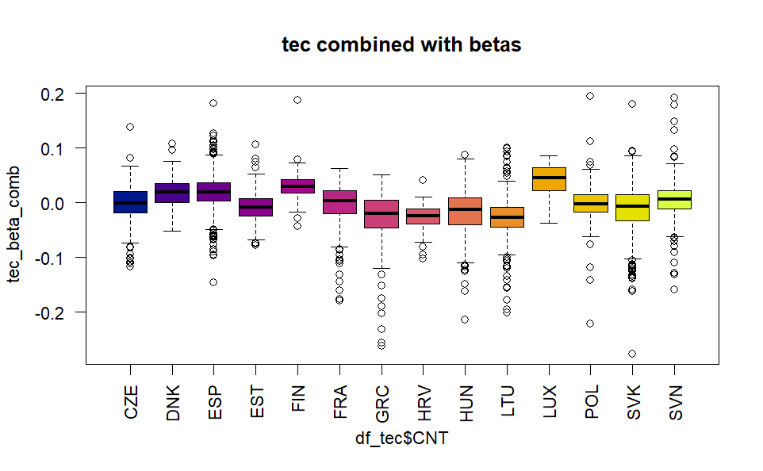

```r
##??
df=data

coeff = coefficients(linear_model)$CNT[1,2:20]
# coefficienti tratti dal summary

tec_beta_comb = 0
tech <- colnames(coeff[grep("tec", vars)])
for (col in tech){
  tec_beta_comb = tec_beta_comb + coeff[,col]*df[,col]

}

psi_beta_comb = 0
psi <- colnames(coeff[grep("psi", vars)])
for (col in psi){
  psi_beta_comb = psi_beta_comb + coeff[,col]*df[,col]

}


clt_beta_comb = 0
clt <- colnames(coeff[grep("clt", vars)])
for (col in clt){
  clt_beta_comb = clt_beta_comb + coeff[,col]*df[,col]

}

fam_beta_comb = 0
fam <- colnames(coeff[grep("fam", vars)])
for (col in clt){
  fam_beta_comb = fam_beta_comb + coeff[,col]*df[,col]

}


tch_beta_comb = 0
tch <- colnames(coeff[grep("tch", vars)])
for (col in clt){
  tch_beta_comb = tch_beta_comb + coeff[,col]*df[,col]

}


sch_beta_comb = 0
sch <- colnames(coeff[grep("sch", vars)])
for (col in clt){
  sch_beta_comb = sch_beta_comb + coeff[,col]*df[,col]

}


##??
df_tec=df
boxplot(tec_beta_comb ~ df_tec$CNT, col=fun_colori(length(unique(df$CNT))),
        las=2,main = "tec combined with betas")
```

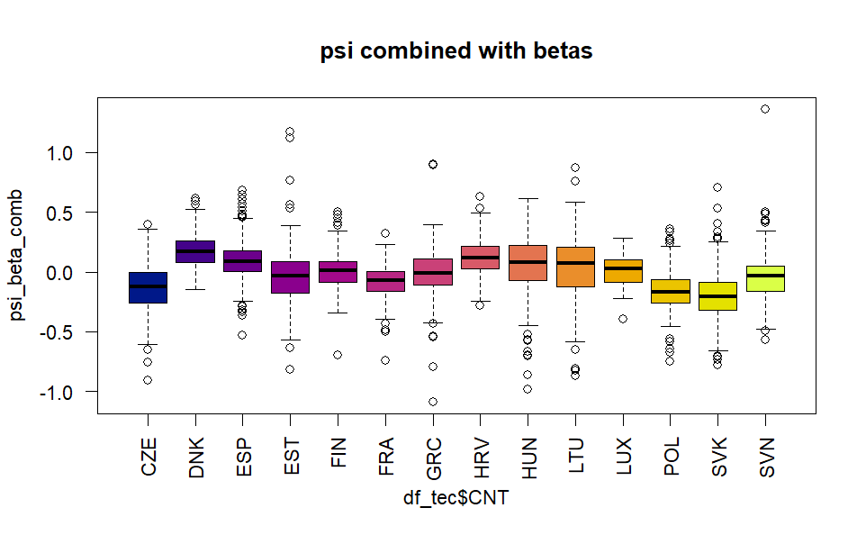

```r
boxplot(psi_beta_comb ~ df_tec$CNT, col=fun_colori(length(unique(df$CNT))),
        las=2,main = "psi combined with betas")
```

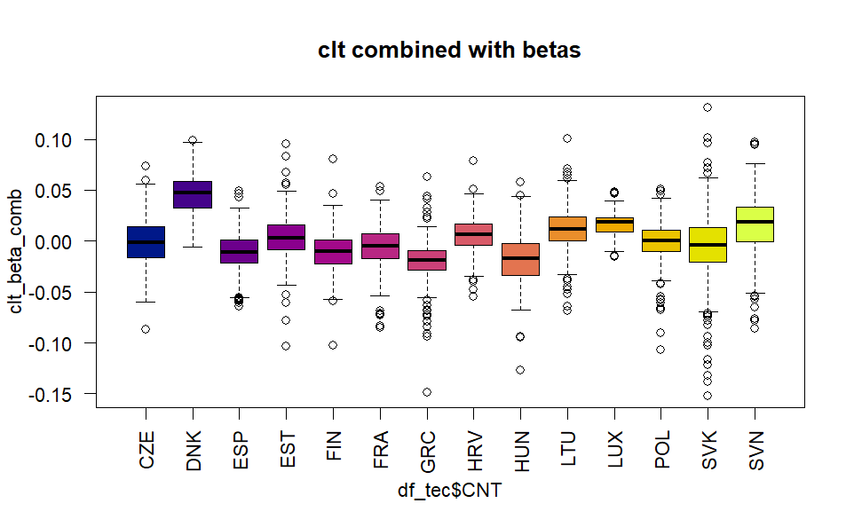

```r
boxplot(clt_beta_comb ~ df_tec$CNT, col=fun_colori(length(unique(df$CNT))),
        las=2,main = "clt combined with betas")
```

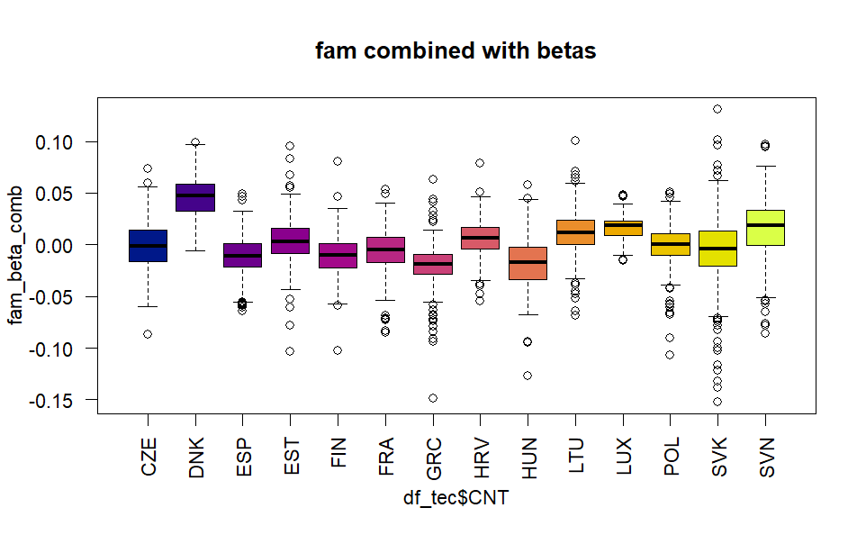

```r
boxplot(fam_beta_comb ~ df_tec$CNT, col=fun_colori(length(unique(df$CNT))),
        las=2,main = "fam combined with betas")
```

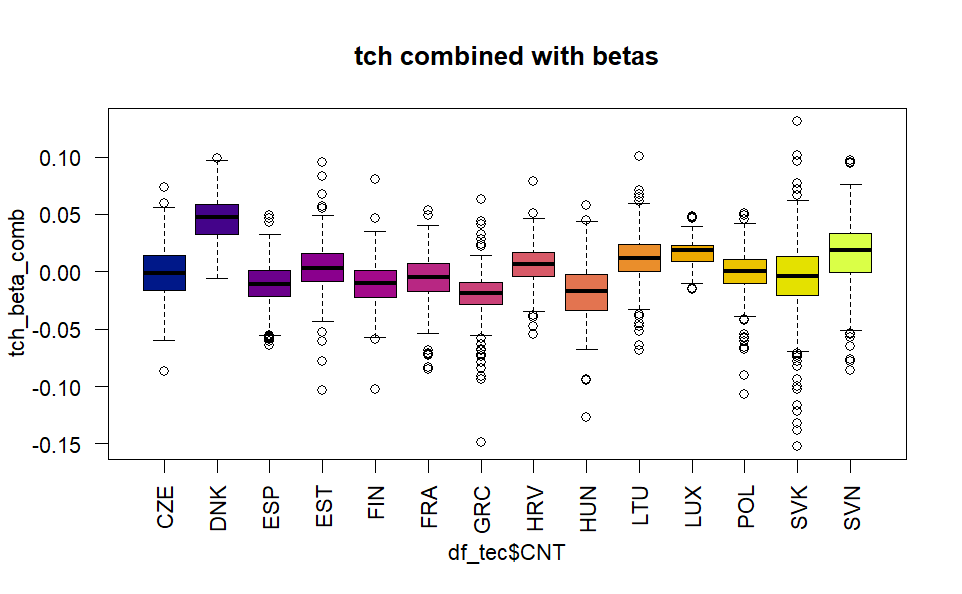

```r
boxplot(tch_beta_comb ~ df_tec$CNT, col=fun_colori(length(unique(df$CNT))),
        las=2,main = "tch combined with betas")
```

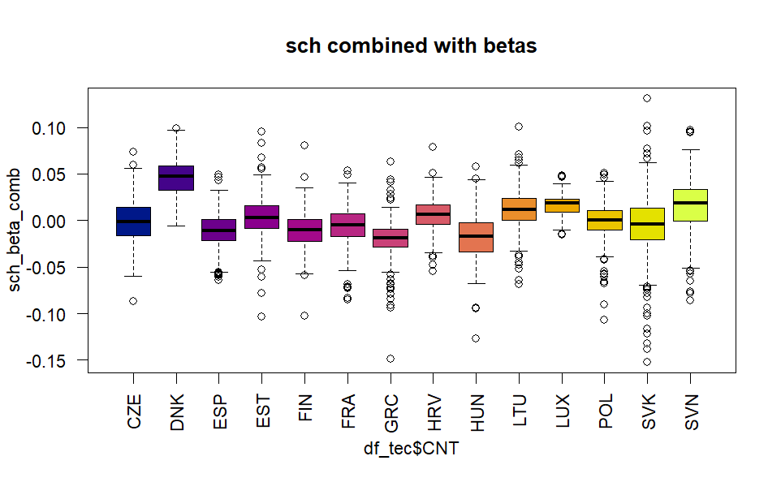

```r
boxplot(sch_beta_comb ~ df_tec$CNT, col=fun_colori(length(unique(df$CNT))),
        las=2,main = "sch combined with betas")
```

```r
val_cur = tec_beta_comb

plot(val_cur, col=cols[as.numeric(as.factor(df$CNT))])
abline(v=breaks, lty=2,col="gray")
text(unique(df$CNT),x=breaks,y=1,cex=0.5)

val_clust = hclust(dist(val_cur,method="euclidean"),method="complete")
plot(val_clust,hang=-0.1, xlab='', labels=F, cex=0.6, sub='')
clusts = cutree(val_clust,k=3)

plot(val_cur, col=cols[as.numeric(as.factor(df$CNT))],pch=clusts)
abline(v=breaks, lty=2,col="gray")
text(unique(df$CNT),x=breaks,y=-0.2,cex=0.5)
```

[output not shown]

```r
val_cur = psi_beta_comb

plot(val_cur, col=cols[as.numeric(as.factor(df$CNT))])
abline(v=breaks, lty=2,col="gray")
text(unique(df$CNT),x=breaks,y=1,cex=0.5)

val_clust = hclust(dist(val_cur,method="euclidean"),method="complete")
plot(val_clust,hang=-0.1, xlab='', labels=F, cex=0.6, sub='')
clusts = cutree(val_clust,k=3)

plot(val_cur, col=cols[as.numeric(as.factor(df$CNT))],pch=clusts)
abline(v=breaks, lty=2,col="gray")
text(unique(df$CNT),x=breaks,y=1,cex=0.5)
```

[output not shown]

```r
val_cur = clt_beta_comb

plot(val_cur, col=cols[as.numeric(as.factor(df$CNT))])
abline(v=breaks, lty=2,col="gray")
text(unique(df$CNT),x=breaks,y=1,cex=0.5)

val_clust = hclust(dist(val_cur,method="euclidean"),method="complete")
plot(val_clust,hang=-0.1, xlab='', labels=F, cex=0.6, sub='')
clusts = cutree(val_clust,k=3)

plot(val_cur, col=cols[as.numeric(as.factor(df$CNT))],pch=clusts)
abline(v=breaks, lty=2,col="gray")
text(unique(df$CNT),x=breaks,y=-0.15,cex=0.5)
```

[output not shown]

# RANDOM EFFECTS

questo pu? darci un’idea del contributo del paese per il well being

```r
rand_eff<-ranef(linear_model)
dotplot(rand_eff)
```

[output not shown]

```r
qqnorm(resid(linear_model))
qqline(resid(linear_model))

qqnorm(unlist(ranef(linear_model)$CNT))
qqline(unlist(ranef(linear_model)$CNT))

hist(resid(linear_model))
```

[output not shown]

# Verify assumptions (used for inference and estimate of parameters)

```r
# * Gaussianity
# * Homoschedasticity
plot(linear_model,col=data$CNT)
boxplot(linear_model_classic$residuals ~ data$CNT, col=unique(data$CNT),
        xlab='countrys', ylab='Residuals')
abline(h=0)


# Comment
#   1. We want to see no pattern: a cloud around the zero
#   2. We want to see a good fit on the line
#   3. Again, we want to see no pattern
#   4. We have the iso-lines of the Cook distance: we can identify the outliers

shapiro.test(residuals(linear_model))
```

[output not shown]

# Variable selection

## **1.** Best Subset Selection (exhaustive search)

```r
# Best Subset Selection
formula_reg = formula(paste(response_variable,"~."))
regfit.full = regsubsets(formula_reg, data=data[,!(colnames(data)=="CNT")],really.big = T)
summary(regfit.full)
```

```r
# Best Subset Selection: we say when we stop
nv_max = number_of_covariates
regfit.full = regsubsets(formula_reg, data=data, nvmax=nv_max,really.big = T)
summary(regfit.full)

reg.summary = summary(regfit.full)

# Which one we choose:
reg.summary$which

# R-squared
reg.summary$rsq

# R.adj^2
reg.summary$adjr2

# SSres (residual sum of squares)
reg.summary$rss

# Plots
par(mfrow=c(1,3))
plot(reg.summary$rsq, xlab="Number of Variables", ylab="R-squared", type="b")
plot(reg.summary$adjr2, xlab="Number of Variables", ylab="Adjusted RSq", type="b")
plot(reg.summary$rss, xlab="Number of Variables", ylab="RSS", type="b")

# We want the model with max r.adj^2 so we extract the coefficients of that model
# Note: ind = how many coefficients has the model
ind = which.max(reg.summary$adjr2)
coef(regfit.full, ind)

# Graphical table of best results
par(mfrow=c(1,2))
plot(regfit.full, scale="r2", main="Exhaustive search")
plot(regfit.full, scale="adjr2", main="Exhaustive search")
```

## **2.** Forward and Backward Stepwise Selection

```r
# Forward
regfit.fwd = regsubsets(formula_reg,data=data,nvmax=nv_max,method="forward")
summary(regfit.fwd)

# Plot
par(mfrow=c(1,3))
plot(summary(regfit.fwd)$rsq, xlab="Number of Variables", ylab="R-squared", type="b")
plot(summary(regfit.fwd)$adjr2, xlab="Number of Variables", ylab="Adjusted RSq", type="b")
plot(summary(regfit.fwd)$rss, xlab="Number of Variables", ylab="RSS", type="b")

par(mfrow=c(1,2))
plot(regfit.fwd,scale="r2",main="Forward Stepwise Selection")
plot(regfit.fwd,scale="adjr2",main="Forward Stepwise Selection")

# Backward
regfit.bwd = regsubsets(formula_reg,data=data,nvmax=nv_max,method="backward")
summary(regfit.bwd)

# Plot
par(mfrow=c(1,3))
plot(summary(regfit.bwd)$rsq, xlab="Number of Variables", ylab="R-squared", type="b")
plot(summary(regfit.bwd)$adjr2, xlab="Number of Variables", ylab="Adjusted RSq", type="b")
plot(summary(regfit.bwd)$rss, xlab="Number of Variables", ylab="RSS", type="b")

par(mfrow=c(1,2))
plot(regfit.bwd,scale="r2",main="Backward Stepwise Selection")
plot(regfit.bwd,scale="adjr2",main="Backward Stepwise Selection")
```

## **3.** Comparison

```r
coef(regfit.full,7) # Exhaustive search
coef(regfit.fwd,7) # Forward Stepwise Selection
coef(regfit.bwd,7) # Backward Stepwise Selection
```

## **4.** K-fold-cross-validation (exhaustive search)

```r
k = 10
folds = sample(1:k,nrow(data),replace=TRUE)
table(folds)

# Function that performs the prediction for regsubsets
predict.regsubsets = function(object,newdata,id){
  form  = as.formula(object$call[[2]])
  mat   = model.matrix(form,newdata)
  coefi = coef(object,id=id)
  xvars = names(coefi)
  mat[,xvars]%*%coefi
}
p = number_of_covariates
cv.errors = matrix(NA,k,p, dimnames=list(NULL, paste(1:number_of_covariates)))

for(j in 1:k){
  best.fit = regsubsets(formula_reg,data=data[folds!=j,],nvmax=number_of_covariates,really.big=T)
  for(i in 1:p){
    pred = predict(best.fit,data[folds==j,],id=i)
    cv.errors[j,i] = mean( (data$Y[folds==j]-pred)^2 )
  }
}

cv.errors

root.mean.cv.errors = sqrt(apply(cv.errors,2,mean)) # average over the columns
root.mean.cv.errors

# Plot
plot(root.mean.cv.errors,type='b')
points(which.min(root.mean.cv.errors),
       root.mean.cv.errors[which.min(root.mean.cv.errors)], col='red',pch=19)
which.min(root.mean.cv.errors)

# Estimation on the full dataset
reg.best = regsubsets(Y~.,data=data, nvmax=number_of_covariates)
coef(reg.best,10)
```

# Inference on Betas

```r
## Assuption: Eps ~ N(0, sigma^2)
## Test (Fisher):
##    H0: (beta1, beta2) == (0, 0)
##    H1: (beta1, beta2) != (0, 0)
r = linear_model_classic$rank - 1  # number of regressors

# needs to be specified
kk=9
linearHypothesis(linear_model, cbind(rep(0,kk),diag(kk)), rep(0,kk))
linear_model
# Comment
#   Pr(>F) = final p-value in summary(fm)
```

# Bonferroni Intervals

```r
alpha = 0.05
n = dim(data)[1]
qT = qt(1-alpha/(2*p), n-(r+1))

vals = 1:20
C = diag(20)
Bf = c()
for(j in vals){
  Bf = rbind(Bf,
         c( (C %*%coefficients(linear_model_classic))[j]-sqrt((C %*%vcov(linear_model_classic) %*% t(C))[j,j])*qT,
            (C %*%coefficients(linear_model_classic))[j]+sqrt((C %*%vcov(linear_model_classic) %*% t(C))[j,j])*qT))
}

Bf = data.frame(Bf)
all(Bf[,1]*Bf[,2]>0)

# Generic beta_j (p, r, n, alpha generici)
# beta_j = c(coefficients(fm)[j]-sqrt(vcov(fm)[j,j])*qt(1-alpha/(2*p), n-(r+1)),
#            coefficients(fm)[j]+sqrt(vcov(fm)[j,j])*qt(1-alpha/(2*p), n-(r+1)))

# Alternatively: Bonferroni's correction
confint(linear_model_classic, level= 1-alpha/p)[vals,]
```

# Inferenza sui beta classic model

```r
## Assuption: Eps ~ N(0, sigma^2)
## Test (Fisher):
##    H0: (beta1, beta2) == (0, 0)
##    H1: (beta1, beta2) != (0, 0)
r = linear_model_classic$rank - 1  # number of regressors

# needs to be specified
kk=19
linearHypothesis(linear_model_classic, cbind(rep(0,kk),diag(kk)), rep(0,kk))
linear_model_classic
```

# Ridge regression classic model

```r
#try a range of lambda values, then choose the one that minimizes generalized cross validation
lambda.c <- seq(30,40,0.01)
#varie prove di intervalli (zoom su quello contenente lambda opt)

#fit.ridge <- lm.ridge(response_variable ~ data$col1_tec+data$col2_tec+data$col3_tec+data$col4_tec+data$col5_tec+data$col1_psi+data$col2_psi+data$col3_psi+data$col4_psi+data$col5_psi+ data$col7_psi+data$col1_clt+data$col2_clt+data$col3_clt+data$col1_fam+data$col1_tch+data$col2_tch+data$col3_tch+data$col4_tch+data$col1_sch+data$col2_sch+data$col3_sch +data$col4_sch,lambda=lambda.c)
fit.ridge <- lm.ridge(formula_classic,data,lambda=lambda.c)

lambda.opt <- lambda.c[which.min(fit.ridge$GCV)]
lambda.opt
#molto dritte, sembrano quasi delle rette (?)

for (i in 1:number_of_covariates) {
  plot(lambda.c,coef(fit.ridge)[,i], type='l', xlab=expression(lambda),
     ylab=expression(beta[i-1]))
  abline(v=lambda.opt, col=2, lty=2)
}

coef.ridge <- coef(fit.ridge)[which.min(fit.ridge$GCV),]
coef.ridge


#lambdaopt=33.95
#              col1_tec    col2_tec    col3_tec    col4_tec    col5_tec    col1_psi    col2_psi    col3_psi    col4_psi    col5_psi    col7_psi    col2_clt    col3_clt
# 0.06927790 -0.02416874  0.06091557  0.03385272  0.02213204  0.04015382  0.43701278 -0.08521387  0.16889777  0.26573159  0.21113793 -0.10879213  0.04765208  0.03400456
#   col1_fam    col1_tch    col2_tch    col1_sch    col2_sch    col4_sch
#-0.02785968  0.05312325 -0.19340668  0.04877980 -0.03586436 -0.04417708

#non identici ma molto simili a coefficienti precedenti
```

# Lasso regression classic model

```r
#predictors matrix and response vector
x <- model.matrix(as.formula(formula_classic),data)[,-1]
y <- data$col6_psi

lambda.grid <- 10^seq(5,-3,length=100)
fit.lasso <- glmnet(x,y, lambda = lambda.grid)

plot(fit.lasso,xvar='lambda',label=TRUE, col = rainbow(dim(x)[2]))
legend('topright', dimnames(x)[[2]], col =  rainbow(dim(x)[2]), lty=1, cex=1)

#cross validation for lambda
cv.lasso <- cv.glmnet(x,y,lambda=lambda.grid)

bestlam.lasso <- cv.lasso$lambda.min
bestlam.lasso

plot(cv.lasso)
abline(v=log(bestlam.lasso), lty=1)


coef.lasso <- predict(fit.lasso, s=bestlam.lasso, type = 'coefficients')[1:20,]
coef.lasso

# (Intercept) data$col1_tec data$col2_tec data$col3_tec data$col4_tec data$col5_tec data$col1_psi data$col2_psi data$col3_psi data$col4_psi data$col5_psi data$col7_psi
#   0.06853704   -0.02285816    0.05934161    0.03282803    0.02167061    0.03967517    0.44227522   -0.08174265    0.16678511    0.26215337    0.20793069   -0.10538030
#data$col2_clt data$col3_clt data$col1_fam data$col1_tch data$col2_tch data$col1_sch data$col2_sch data$col4_sch
#   0.04682972    0.03334747   -0.02698860    0.05121214   -0.19250747    0.04835701   -0.03490630   -0.04370465
#nessuna componente va a 0
#ancora coefficienti molto simili ai precedenti
```

# Provare con gli alberi

```r
attach(data)


tree.tec <- tree(COMPICT ~ ICTCLASS+ICTHOME+ICTOUTSIDE+ICTRES+ENTUSE+AUTICT,data)
summary(tree.tec)

plot(tree.tec)
text(tree.tec,pretty=0)

cv.tec <- cv.tree(tree.tec)
plot(cv.tec$size,cv.tec$dev,type='b',xlab='size',ylab='deviance')

#pruning per ridurre albero anche se solo una variabile considerata
prune.tec <- prune.tree(tree.tec,best=4)
plot(prune.tec)
text(prune.tec,pretty=0)

#considera solo autict

detach(data)
```